# Neural Network Classification

Seif Kungulio

2025-02-08

### **Business Understanding**

#### **Problem Statement**

In this analysis, we aim to predict if a stock will pay a dividend.

### **Data Understanding**

#### **Dataset Overview**

The dataset contains six (6) variables on 200 stocks. Each row represents information on a different stock. The first or last column is typically the outcome variable in data mining. The data indicates if a stock had a dividend (Yes = 1; No = 0). In this case, “dividend” is the response variable in the first column.

#### **Data Dictionary**

| Variable | Definition | Data Type | Constraints/ Rules |
| --- | --- | --- | --- |
| **dividend** | A portion of a company’s earnings is distributed to shareholders as a return on their investment. | Integer | It must be 1 0r 0 not negative |
| **fcfps** | Free Cash Flow Per Share (fcfps) - A measure of a company’s ability to generate cash after accounting for capital expenditures, calculated by dividing free cash flow by the number of outstanding share… | Numeric | It must be number |
| **earnings_growth** | The percentage increase or decrease in a company’s earnings over a specific period indicates financial performance and future profitability. | Numeric | It must be a number |
| **de** | Debt-to-Equity Ratio (DE) - A financial metric that compares a company’s total debt to its shareholders’ equity, indicating the proportion of debt used to finance its operations relative to equity. | Numeric | It must be a number |
| **mcap** | Market Capitalization (MCAP) - The total value of a company’s outstanding shares, calculated by multiplying the current share price by the total number of shares outstanding. | Integer | It must be positive |
| **current_ratio** | A liquidity ratio that measures a company’s ability to pay its short-term liabilities with its short-term assets, calculated by dividing current assets by current liabilities. | Numeric | It must be a number |

### **Data Preparation**

#### **Load Necessary Libraries and the Dataset**

Install and Load necessary libraries

```r
# Install the libraries if they are not installed
if (!requireNamespace("neuralnet", quietly = TRUE)) {
  install.packages("neuralnet")
}
if (!requireNamespace("pROC", quietly = TRUE)) {
  install.packages("pROC")
}
if (!requireNamespace("ggplot2", quietly = TRUE)) {
  install.packages("ggplot2")
}

# Load the libraries
library(neuralnet)
library(pROC)
library(ggplot2)
```

Load the dataset and name it dividend.df

```r
dividend.df <- read.csv("resource/dividend_info.csv")
```

Check the dimensions of the data frame

```r
dim(dividend.df)
```

```
## [1] 200   6
```

Show the first six rows to check the data

```r
head(dividend.df)
```

```
##   dividend fcfps earnings_growth   de mcap current_ratio
## 1        0  2.75          -19.25 1.11  545     0.9240557
## 2        1  4.96            0.83 1.09  630     1.4685722
## 3        1  2.78            1.09 0.19  562     1.9758751
## 4        0  0.43           12.97 1.70  388     1.9419977
## 5        1  2.94            2.44 1.83  684     2.4874670
## 6        1  3.90           -6.29 0.46  621     1.7832525
```

#### **Exploratory Data Analysis**

Determine the type (class) of each variable in R Print the list of variables

```r
variable_names <- names(dividend.df)
```

Use sapply to get the class of each variable

```r
variable_classes <- sapply(dividend.df, class)
```

Combine variable names and classes into a data frame

```r
result_df <- data.frame(Variable = variable_names, Class = variable_classes)
```

Print the result

```r
print(result_df)
```

```
##                        Variable   Class
## dividend               dividend integer
## fcfps                     fcfps numeric
## earnings_growth earnings_growth numeric
## de                           de numeric
## mcap                       mcap integer
## current_ratio     current_ratio numeric
```

Determine the type (class) of each variable in R using the str() function

```r
str(dividend.df)
```

```
## 'data.frame':    200 obs. of  6 variables:
##  $ dividend       : int  0 1 1 0 1 1 1 0 1 1 ...
##  $ fcfps          : num  2.75 4.96 2.78 0.43 2.94 3.9 1.09 2.32 2.5 4.46 ...
##  $ earnings_growth: num  -19.25 0.83 1.09 12.97 2.44 ...
##  $ de             : num  1.11 1.09 0.19 1.7 1.83 0.46 2.32 3.34 3.15 3.33 ...
##  $ mcap           : int  545 630 562 388 684 621 656 351 658 330 ...
##  $ current_ratio  : num  0.924 1.469 1.976 1.942 2.487 ...
```

Determine the summary statistics for each column

```r
summary(dividend.df)
```

```
##     dividend        fcfps       earnings_growth        de
##  Min.   :0.00   Min.   :0.070   Min.   :-19.25   Min.   :0.060
##  1st Qu.:0.00   1st Qu.:1.295   1st Qu.:  0.17   1st Qu.:1.450
##  Median :1.00   Median :2.085   Median : 11.05   Median :2.195
##  Mean   :0.51   Mean   :2.266   Mean   : 11.59   Mean   :2.138
##  3rd Qu.:1.00   3rd Qu.:3.040   3rd Qu.: 24.16   3rd Qu.:2.930
##  Max.   :1.00   Max.   :5.000   Max.   : 40.10   Max.   :3.990
##       mcap       current_ratio
##  Min.   :103.0   Min.   :0.001436
##  1st Qu.:289.5   1st Qu.:1.038044
##  Median :380.5   Median :1.508622
##  Mean   :417.9   Mean   :1.502255
##  3rd Qu.:551.2   3rd Qu.:1.960627
##  Max.   :799.0   Max.   :2.905462
```

#### **Handle Missing Values**

Check for missing values in the data

```r
missing_values <- colSums(is.na(dividend.df))
```

Print the columns with missing values and their counts

```r
print(missing_values[missing_values > 0])
```

```
## named numeric(0)
```

#### **Check and Handle Duplicates**

Check for duplicate entries in dividend.df

```r
dupes <- dividend.df[duplicated(dividend.df) | duplicated(dividend.df, fromLast = TRUE), ]
```

Print or inspect the duplicate entries

```r
print(dupes)
```

```
## [1] dividend        fcfps           earnings_growth de
## [5] mcap            current_ratio
## <0 rows> (or 0-length row.names)
```

#### **Exploration Through Visualization**

Create side-by-side box plots for 0 dividend and 1 dividend

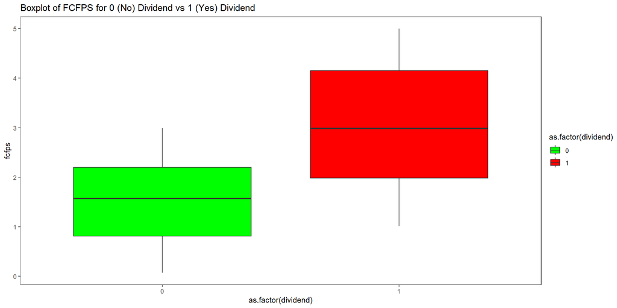

```r
ggplot(dividend.df, aes(x = as.factor(dividend),
                        y = fcfps,
                        fill = as.factor(dividend))) +
  geom_boxplot() +
  labs(title = "Boxplot of FCFPS for 0 (No) Dividend vs 1 (Yes) Dividend") +
  theme_test() +
  scale_fill_manual(values = c("green", "red"))
```

Create side-by-side boxplots for dividend (x-axis) and earnings_growth (y-axis) with green and red colors

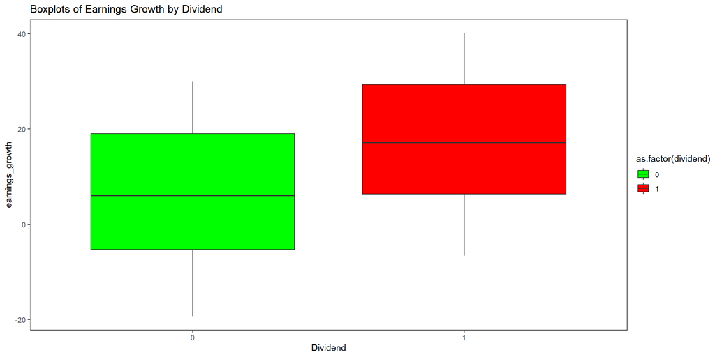

```r
ggplot(dividend.df, aes(x = as.factor(dividend),
                        y = earnings_growth,
                        fill = as.factor(dividend))) +
  geom_boxplot() +  # Add boxplots
  labs(title = "Boxplots of Earnings Growth by Dividend",
       x = "Dividend",
       y = "earnings_growth") +  # Set plot title and axis labels
  theme_test() +  # Set plot theme
  scale_fill_manual(values = c("green", "red"))  # Set boxplot fill colors
```

Create side-by-side boxplots for dividend (x-axis) and de (y-axis) with green and red colors

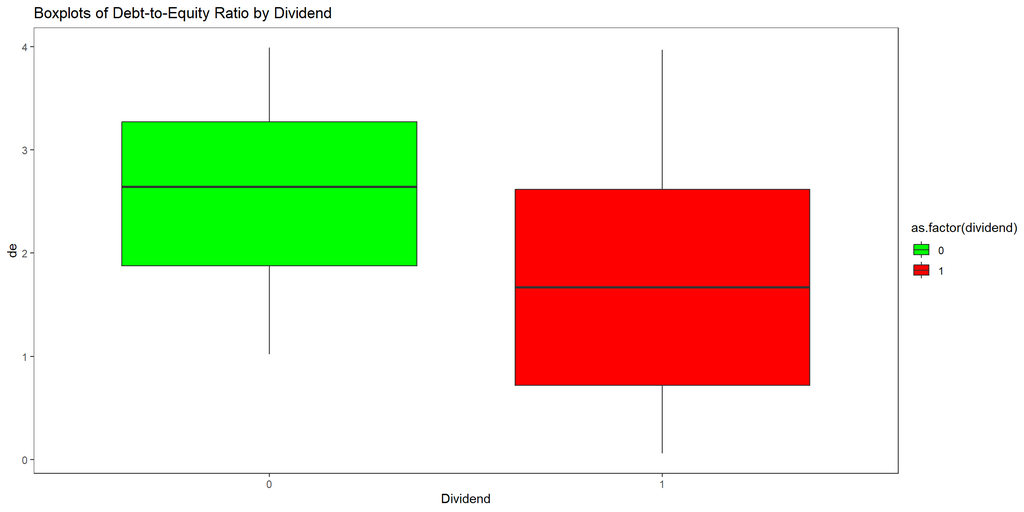

```r
ggplot(dividend.df, aes(x = as.factor(dividend),
                        y = de, fill = as.factor(dividend))) +
  geom_boxplot() +  # Add boxplots
  labs(title = "Boxplots of Debt-to-Equity Ratio by Dividend",
       x = "Dividend", y = "de") +  # Set plot title and axis labels
  theme_test() +  # Set plot theme
  scale_fill_manual(values = c("green", "red"))  # Set boxplot fill colors
```

Create side-by-side boxplots for dividend (x-axis) and market capitalization (y-axis) with green and red colors

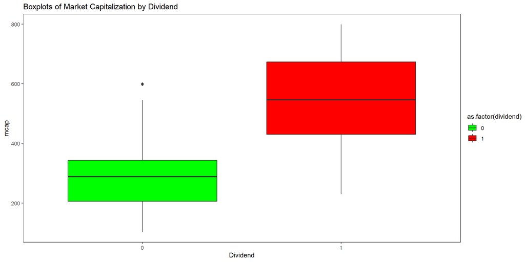

```r
ggplot(dividend.df, aes(x = as.factor(dividend),
                        y = mcap, fill = as.factor(dividend))) +
  geom_boxplot() +  # Add boxplots
  labs(title = "Boxplots of Market Capitalization by Dividend",
       x = "Dividend", y = "mcap") +  # Set plot title and axis labels
  theme_test() +  # Set plot theme
  scale_fill_manual(values = c("green", "red"))  # Set boxplot fill colors
```

```r
# Remove rows where mcap is greater than 580
dividend.df <- dividend.df[dividend.df$mcap <= 580, ]
```

Create side-by-side boxplots for dividend (x-axis) and current_ratio (y-axis) with green and red colors

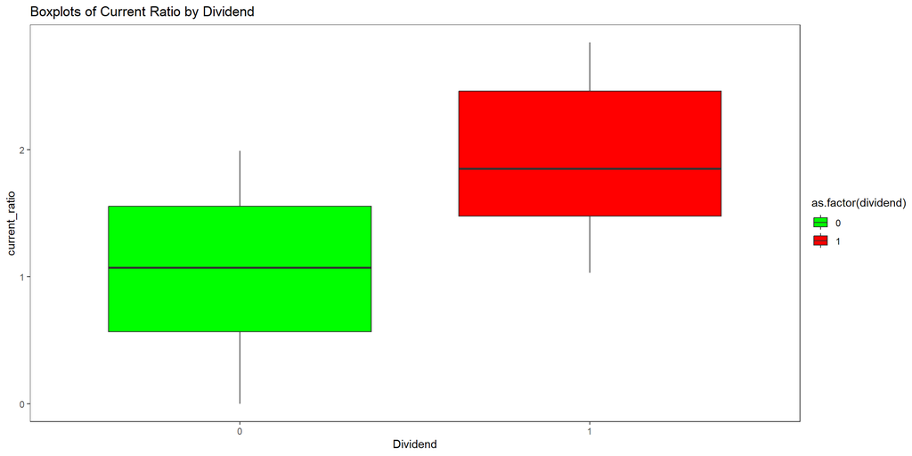

```r
ggplot(dividend.df, aes(x = as.factor(dividend),
                        y = current_ratio,
                        fill = as.factor(dividend))) +
  geom_boxplot() +  # Add boxplots
  labs(title = "Boxplots of Current Ratio by Dividend",
       x = "Dividend", y = "current_ratio") +  # Set plot title and axis labels
  theme_test() +  # Set plot theme
  scale_fill_manual(values = c("green", "red"))  # Set boxplot fill colors
```

[figure not shown]